# Project Python Foundations: FoodHub Data Analysis

### **Question 13:** The company wants to provide a promotional offer in the advertisement of the restaurants. The condition to get the offer is that the restaurants must have a rating count of more than 50 and the average rating should be greater than 4. Find the restaurants fulfilling the criteria to get the promotional offer. [3 marks]

```python
#Remove 'Not given' ratings and convert ratings to int BUT MAKE IT A COPY FOR NOW
non_nulls = df[df['rating'] != 'Not given'].copy()
non_nulls['rating'] = non_nulls['rating'].astype(int)

#group by restaurant name abd rating counts in descending order
rating_count = non_nulls.groupby('restaurant_name')['rating'].count().sort_values(ascending=False).reset_index()

#create a variable for the resturaunts with at least 50 ratings
popular_restaurants = rating_count[rating_count['rating'] > 50]['restaurant_name']

# only grab restaurants with at least 50 ratings
filtered = non_nulls[non_nulls['restaurant_name'].isin(popular_restaurants)].copy()

# Calculate the mean rating for these popular restaurants
top_rated_restaurants = (filtered
    .groupby('restaurant_name')['rating']
    .mean()
    .reset_index()
    .sort_values(by='rating', ascending=False)
)

#we only want ones with a rating greater than 4
top_rated_restaurants = top_rated_restaurants[top_rated_restaurants['rating'] > 4].reset_index(drop=True)

top_rated_restaurants
```

|  | restaurant_name | rating |
| --- | --- | --- |
| 0 | The Meatball Shop | 4.511905 |
| 1 | Blue Ribbon Fried Chicken | 4.328125 |
| 2 | Shake Shack | 4.278195 |
| 3 | Blue Ribbon Sushi | 4.219178 |

blue ribbon fried chicken is a good sign for our southern food promo and the variety shows that we may have success with more exotic foods from our better margin restaurants. but the list also contains a good amount of the restaurants that have the most total orders showing that people may have their preffered places of eating that may be tough to break... we really wont know until we try though!

#### Observations:

there are only 4 resturaunts with an average rating over 4 that has 50 ratings and the meatball shop gets the highest reviews in this basket

### **Question 14:** The company charges the restaurant 25% on the orders having cost greater than 20 dollars and 15% on the orders having cost greater than 5 dollars. Find the net revenue generated by the company across all orders. [3 marks]

```python
def rev(x):
    if x > 20:
        return x*0.25
    elif x > 5:
        return x*0.15
    else:
        return x*0

df['revenue'] = df['cost_of_the_order'].apply(rev)
df.head()
```

|  | order_id | customer_id | restaurant_name | cuisine_type | cost_of_the_order | day_of_the_week | rating | food_preparation_time | delivery_time | revenue |
| --- | --- | --- | --- | --- | --- | --- | --- | --- | --- | --- |
| 0 | 1477147 | 337525 | Hangawi | Korean | 30.75 | Weekend | Not given | 25 | 20 | 7.6875 |
| 1 | 1477685 | 358141 | Blue Ribbon Sushi Izakaya | Japanese | 12.08 | Weekend | Not given | 25 | 23 | 1.8120 |
| 2 | 1477070 | 66393 | Cafe Habana | Mexican | 12.23 | Weekday | 5 | 23 | 28 | 1.8345 |
| 3 | 1477334 | 106968 | Blue Ribbon Fried Chicken | American | 29.20 | Weekend | 3 | 25 | 15 | 7.3000 |
| 4 | 1478249 | 76942 | Dirty Bird to Go | American | 11.59 | Weekday | 4 | 25 | 24 | 1.7385 |

```python
total_rev = df['revenue'].sum()
total_rev
```

```
6166.303
```

the total revenue is $6,166.30

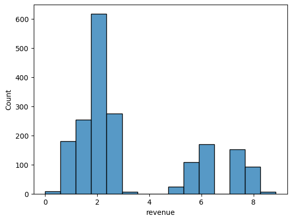

```python
sns.histplot(df['revenue'])
```

this might be a good place to start when creating new bins

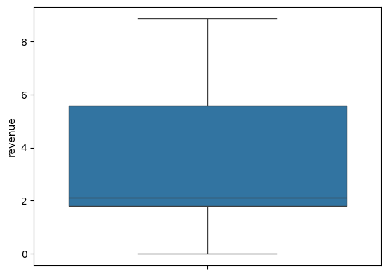

```python
sns.boxplot(df['revenue'])
```

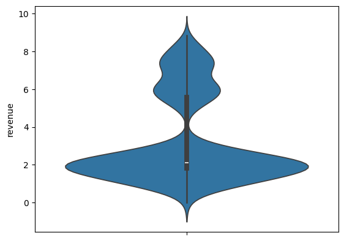

```python
sns.violinplot(df['revenue'])
```

now that we have the revenue per order lets find out which restaurants give us the best average revenue but also what their rating is and what cuisine type they are. this will help us decide if we want to change our pricing model, promote certain restaurants to certain consumers, or introduce customers to new cuisine types that are on average more profitable. but to do that we need more data types and more complete data.

```python
# Convert ratings to numeric, forcing errors to NaN
df['rating'] = pd.to_numeric(df['rating'], errors='coerce')

df = df.dropna(subset=['rating'])

# Group by restaurant name and calculate the average revenue, average rating, and cuisine type for each restaurant
average_revenue_rating_cuisine = df.groupby('restaurant_name').agg(
    average_revenue=('revenue', 'mean'),
    average_rating=('rating', 'mean'),
    cuisine_type=('cuisine_type', 'first')
).reset_index()

# Sort descending order
highest_average_revenue = average_revenue_rating_cuisine.sort_values(by='average_revenue', ascending=False)

# Display the top restaurants in differnt cuisine types with the highest average revenue per order
top_restaurants = highest_average_revenue.head(25)
print(top_restaurants)
```

```
                           restaurant_name  average_revenue  average_rating  \
72                       Kambi Ramen House         8.232500        5.000000
36                            Delicatessen         7.509167        4.333333
58                      Haru Gramercy Park         7.457500        5.000000
66                              Il Bambino         7.312500        4.000000
13                     Bhatti Indian Grill         7.312500        5.000000
79                            Lucky Strike         7.312500        4.000000
110                             Sarabeth's         7.283333        4.000000
74                                   Klong         7.262500        5.000000
3                                67 Burger         7.262500        5.000000
12                                Benihana         6.813750        4.500000
2                          5 Napkin Burger         6.783750        4.000000
71                                  Junoon         6.738333        5.000000
119             Song Thai Restaurant & Bar         6.675000        5.000000
46                           DuMont Burger         6.662500        4.000000
```

[output cut: 38 more lines]

#### Observations:

we dont neccessarily have to introduce people to new cuisine types... for people who love american food thre are some good amrican options which ahve better margins for us.

### **Question 15:** The company wants to analyze the total time required to deliver the food. What percentage of orders take more than 60 minutes to get delivered from the time the order is placed? (The food has to be prepared and then delivered.) [2 marks]

```python
#create a new variable
df['total_time'] = df['food_preparation_time'] + df['delivery_time']

#get the count of orders over 60
over_60 = (df['total_time'] > 60).sum()
# get the total number of orders
total_entries = len(df['total_time'])
#divide the count of the ones over 60 by the total multiply by 100 to get the %
percentage_over_60 = (over_60 / total_entries) * 100

percentage_over_60
```

```
10.240963855421686
```

10.24096%

60 minutes is a long time to wait maybe total time has an impact on rating...

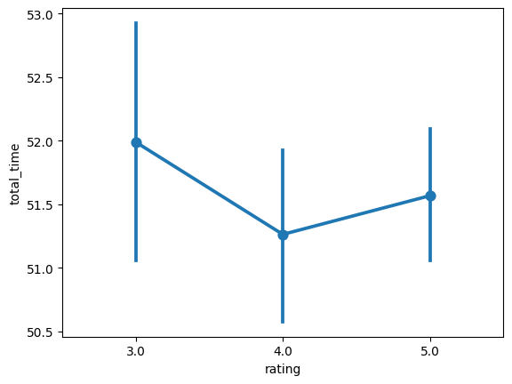

```python
sns.pointplot(data=df, x='rating', y='total_time')
```

its still a game of inches here for the most part something we should try to improve on but i think our other changes would be more yielding in the near term. still, gis analysis of common routes between certain restaurants, ratings, cuisine types, and our margins and the time equation would be interesting later down the road but right now we dont have the money or the data to do that level of research.

### **Question 16:** The company wants to analyze the delivery time of the orders on weekdays and weekends. How does the mean delivery time vary during weekdays and weekends? [2 marks]

```python
df.groupby('day_of_the_week')['delivery_time'].mean()
```

| day_of_the_week | delivery_time |
| --- | --- |
| Weekday | 28.305882 |
| Weekend | 22.436740 |

**dtype:** float64

#### Observations:

there is a big diference between weekend and weekday... weekend time is less than weekday. keep in mind this is after i dropped some data. since most of the demand is during the weekend this is good

```python
df.groupby('day_of_the_week')['total_time'].mean()
```

| day_of_the_week | total_time |
| --- | --- |
| Weekday | 55.567647 |
| Weekend | 49.867397 |

**dtype:** float64

```python
df['rating'].dtype
```

```
dtype('float64')
```

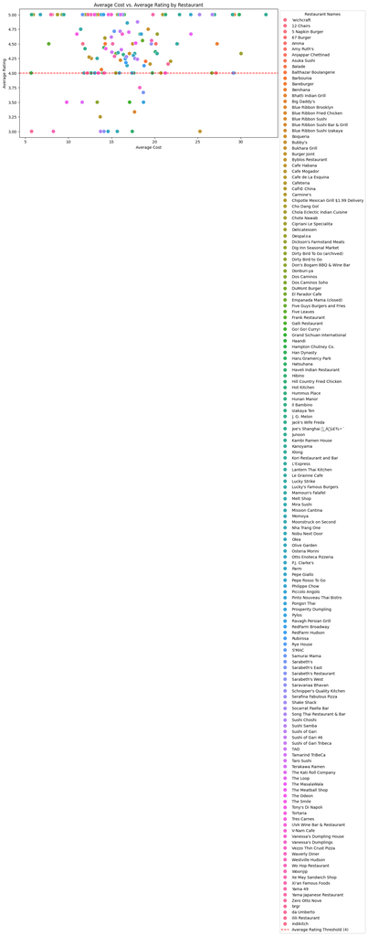

```python
# Ensure that 'rating' is numeric
df['rating'] = pd.to_numeric(df['rating'], errors='coerce')

# Calculate the average rating and average cost grouped by restaurant name
aggregated_data = df.groupby('restaurant_name').agg(
    average_rating=('rating', 'mean'),
    average_cost=('cost_of_the_order', 'mean')
).reset_index()

plt.figure(figsize=(12, 6))

sns.scatterplot(data=aggregated_data, x='average_cost', y='average_rating', hue='restaurant_name', s=100)

plt.title('Average Cost vs. Average Rating by Restaurant')
plt.xlabel('Average Cost')
plt.ylabel('Average Rating')
plt.axhline(y=4, color='r', linestyle='--', label='Average Rating Threshold (4)')
plt.legend(loc='upper left', bbox_to_anchor=(1, 1), title='Restaurant Names')
plt.tight_layout()

plt.show()
```

there is an outlier or cluster of outliers that is impacting the data here it would otherwise potentially be at least slightly more corrolated. if i had more time i would investigate this further but i dont know how and i think its beyond the scope of the project.

### Conclusion and Recommendations

### **Question 17:** What are your conclusions from the analysis? What recommendations would you like to share to help improve the business? (You can use cuisine type and feedback ratings to drive your business recommendations.) [6 marks]

### Conclusions:

- none of the numerical columns were correlated
- there are lots of not givens for rating
- none of the most visited restaurants are ones with the highest average costs...
- our margins are not calculated the best

### Recommendations:

- we should do a promo for surveys or something to get more accurate data on ratings especially first time users or people who aren’t addicted to the instant gratification we provide
- we should promote the highest average cost restaurants to beef up our margins
- we should try purchasing customer data to improve the reccomendation system we plan on building to boost margins
- we might want to think about a more in depth gis analysis after we imprve the ratings issue
- right now we should focus mainly on deciding whether we are going to change our bins for our margins, promote certian better yilding restauraunts to most likely takers personally or if we want to promote certain cuisine types to get people hooked to those food types. we may do one or all three and how we go about it is important because the pricing model needs to reflect what we expect the distribution to be once we get new restaurant margins!